# Analyzing Countries' Relative Event Performance in the WCA

#### Authors: Will Callan, Sean Belke, Adam Gradess

## Introduction

The [Rubik's Cube](https://www.smithsonianmag.com/innovation/brief-history-rubiks-cube-180975911/) is one of the most popular and best-selling toys in the history of the world. Invented in 1974 by Hungarian architect Erno Rubik, the cube has fascinated minds and captivated enthusiasts for decades. It didn't take long for a competitive community surrounding the cube to develop along with an officiating organization, the World Cube Association (WCA). The first official WCA competition was the World Championship held in 1982 in Budapest, Hungary. [Minh Thai](https://www.speedsolving.com/wiki/index.php/Minh_Thai) won the competition, with his fastest solve coming in at 22.95 seconds.

Speedcubing has come quite a long way since the original 1982 world championship. These days, a 22 second solve wouldn't get you past the first round in a local competition, let alone get you first place at the world championship. Countless advancements have been made in speedsolving methods, perhaps most notably the development and refinement of the [CFOP or Fridrich Method](https://www.rubiks.com/en-us/blog/how-to-solve-the-rubiks-cube-fridrich-method-cfop-stage-1), which is by far the most widely used 3x3 speedsolving method today.

Speedcubing has expanded in many other ways as well. While the original world championship only had the 3x3x3 Rubik's Cube, today the WCA recognizes 17 different events. Some of them are straightforward variations on the 3x3x3 Rubik's cube, such as the smaller 2x2x2 Rubik's Cube, or some larger cubes (up to 7x7x7). Some other events that the WCA recognizes include:

- [3x3x3 One-Handed](https://www.youtube.com/watch?v=LvFtz4QAP5g)
- [3x3x3 Blindfolded](https://www.youtube.com/watch?v=MJew86mY3wY)
- [Pyraminx](https://www.youtube.com/watch?v=buod0m1u-qU)
- [Skewb](https://www.youtube.com/watch?v=p-b2PW9CQho)
- [Square-1](https://www.youtube.com/watch?v=4LSLK_CGIus)

The three of us have been speedcubing for at least 7 years each. One observation that we made over the years is that certain events seemed to be more popular in certain countries. The most notable example of this that I can recall was Poland's dominance in the Skewb event. For example, back in 2017, the top 3 skewb average results in the world were all from [Polish cubers](https://www.worldcubeassociation.org/results/rankings/skewb/average?years=until+2017). It's possible that this is mostly just a coincidence. But this leads into what we will be investigating in this project. We wish to test the strength of the connection between the events that a cuber ranks the highest in and competes the most in with their country of residence. Are there other subtle relationships between certain countries and certain events? And finally, we will use machine learning to learn a model that will predict the most likely country of residence of a particular cuber based on the events that they rank the highest in. Hopefully, we will be able to predict their country of residence with a better accuracy than a random guess would yield.

### Obtaining Data

If you wish to follow along with this tutorial, start by creating a working directory to hold the WCA data and your Jupyter Notebook.

The WCA's data can be downloaded [here](https://www.worldcubeassociation.org/results/misc/export.html). Click on the link for the TSV zip file, download it, and then extract the files to some folder (not your working directory). Inside the extracted folder there are numerous files, most of which we won't need. Move the following files into your working directory:

- WCA_export_Persons.tsv
- WCA_export_RanksAverage.tsv
- WCA_export_RanksSingle.tsv
- WCA_export_Results.tsv
- WCA_export_Countries.tsv

At this point you should also create your Jupyter Notebook (in the same directory).

The data that we need to use for this analysis is not all in the same file, so we will need to create a few separate dataframes and then merge and wrangle them a bit to get them in the format that we want.

### Warming Up

While most people have heard of the Rubik's Cube, most have not attended a WCA competition, and likely do not know how these competitions work. So before jumping into the heart of our country-based analysis, let's get our hands dirty with some of this data. This will familiarize the reader with parts of the dataset that will be used later, and will provide an opportunity to explain some aspects of cubing that are relevant to our analysis.

To begin, let's load in the RanksAverage and RanksSingle datasets and then wrangle them into a useful form.

```python
import numpy as np
import pandas as pd
import seaborn as sns
import matplotlib.pyplot as plt

# Note: the low_memory parameter is critical here.
# Without it, we would have inconsistencies in our datatypes, which would require a bit more wrangling to resolve.
df_average = pd.read_csv("WCA_export_RanksAverage.tsv", sep = '\t', low_memory=False)
df_single = pd.read_csv("WCA_export_RanksSingle.tsv", sep = '\t', low_memory=False)

print("Averages: \n", df_average.head())
print("\nSingles: \n", df_single.head())
```

```
Averages:
      personId eventId  best  worldRank  continentRank  countryRank
0  2018KHAN28     222   105          1              1            1
1  2013EGDA02     222   121          2              1            1
2  2012CALL01     222   123          3              2            2
3  2016LIJI05     222   125          4              1            1
4  2012PATE01     222   127          5              2            1

Singles:
      personId eventId  best  worldRank  continentRank  countryRank
0  2014CZAP01     222    49          1              1            1
1  2017AGGA01     222    51          2              1            1
2  2014RZEW01     222    52          3              2            2
3  2015ZUBO01     222    52          3              2            2
4  2016JONE04     222    53          5              1            1
```

Let's pause here to sort through what we're looking at.

How do we interpret one of these rows? Let's interpret the first row in each table.

- Averages table: The competitor with the WCA ID 2018KHAN28 ([Zayn Khanani](https://www.worldcubeassociation.org/persons/2018KHAN28)) has a personal best official 2x2x2 average of 1.05 seconds. This is ranked number 1 in the world (and obviously, number 1 in the continent and country as well).
- Singles table: The competitor with the WCA ID 2014CZAP01 ([Maciej Czapiewski](https://www.worldcubeassociation.org/persons/2014CZAP01)) has a personal best official 2x2x2 single of 0.49 seconds. This is ranked number 1 in the world (and obviously, number 1 in the continent and country as well).

A competitor's best single is exactly as you would expect - it is the fastest solve they have ever completed in an official competition. The average is a little more complicated. For most events, such as 2x2x2 through 5x5x5, competitors complete 5 solves for an average. The best and worst solves are dropped off, and the mean of the middle 3 is calculated and recorded as their "average of 5." For some other events however, such as 6x6x6 and 7x7x7, competitors only complete 3 solves, and their average is computed as the mean of those three times. So since the top of the ranks table has 2x2x2 results, we're looking at the best average of 5 that each of these competitors has completed in competition.

The reader may notice that the times are given in centiseconds (e.g., 49 for 0.49 seconds). We'd like to replace these with their value in seconds, as a float. We'll also drop a few events that are not recognized anymore, drop continental and country ranks entirely, and then merge these two into a single dataframe.

```python
df = pd.merge(df_single, df_average, how='right', on=['personId', 'eventId'])

# drop continental and country ranks since we don't need them for our analysis (we'll just focus on world rankings)
df.drop(['continentRank_x', 'countryRank_x', 'continentRank_y', 'countryRank_y'], axis = 1, inplace=True)

# rename columns to more descriptive names after the merge
df.rename({'best_x': 'best_single', 'worldRank_x': 'worldRank_single', 'best_y': 'best_average', \
    'worldRank_y': 'worldRank_average'}, axis = 1, inplace = True)

# scale the times to what they actually are (by default, times like 0.49 seconds were recorded as 49)
df['best_single'] = np.float64(df['best_single'] / 100.0)
df['best_average'] = np.float64(df['best_average'] / 100.0)

# Magic (eventId magic) and Master Magic (eventId mmagic) are old events that are not recognized anymore, so we drop them.
df.drop(df[df['eventId'] == 'magic'].index, inplace=True)
df.drop(df[df['eventId'] == 'mmagic'].index, inplace=True)

df.head()
```

|  | personId | eventId | best_single | worldRank_single | best_average | worldRank_average |
| --- | --- | --- | --- | --- | --- | --- |
| 0 | 2018KHAN28 | 222 | 0.68 | 36 | 1.05 | 1 |
| 1 | 2013EGDA02 | 222 | 0.72 | 58 | 1.21 | 2 |
| 2 | 2012CALL01 | 222 | 0.62 | 22 | 1.23 | 3 |
| 3 | 2016LIJI05 | 222 | 0.89 | 145 | 1.25 | 4 |
| 4 | 2012PATE01 | 222 | 0.69 | 41 | 1.27 | 5 |

So what analysis could we do with just this information alone? One thing we could examine is the relationship between cubers' best singles and averages for different events. Let's start by making a scatterplot (along with a line of best fit) for the top 200 competitors (based on average) for a few different events to see if we notice any disparities.

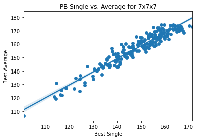

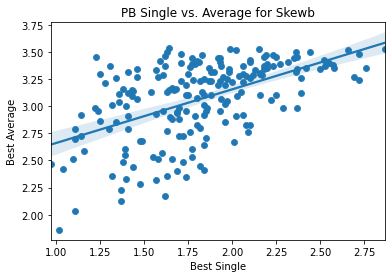

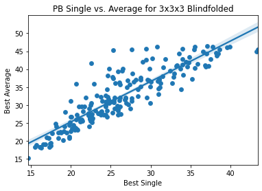

```python
def plot_event(sample_data, event_name):
    # plot their PB single (x-axis) vs. their PB average (y-axis)
    ax = sns.scatterplot(data = sample_data, x = 'best_single', y = 'best_average')

    # plot a line of best fit for the data
    sns.regplot(ax = ax, data = sample_data, x = 'best_single', y = 'best_average')

    ax.set_xlabel('Best Single')
    ax.set_ylabel('Best Average')
    ax.set_title('PB Single vs. Average for ' + event_name);

plot_event(df[df['eventId'] == '777'][0:200], "7x7x7")
plt.figure()
plot_event(df[df['eventId'] == 'skewb'][0:200], "Skewb")
plt.figure()
plot_event(df[df['eventId'] == '333bf'][0:200], "3x3x3 Blindfolded")
```

The 7x7x7 data certainly looks to fit the line the best, and the other two each have a distinctness to their "shapes". I think the most interesting aspect of these 3 plots is the upward bulge in the 3x3x3 blindfolded plot. The 3x3x3 blindfolded event uses a mean of 3 instead of average of 5. This means that none of the solves are dropped, so if any one of your solves is a DNF (did not finish), which happens quite often in blindfolded events due to mistakes in memorization of the cube, your entire average will not count. Because of this, in competition people will often aim for the fastest possible single most of the time. This leads to a lot of DNF averages, but every once in a while a competitor will get a very fast single. Occasionally, a fast blind solver may decide to play it safe for one round and specifically try to get a complete mean of 3. I think that this is why we see the data spreading out a bit over the regression line - this is from cubers that are purposefully trying to go slower for a better chance of solving the cube in order to get a mean, after they've already gotten a really good single.

Hopefully that small introduction to the data was helpful and you are now more familiar with the WCA and Rubik's Cube Competitions. Now let's shift gears to the main part of our analysis - examining the relationship between countries and events.

### Motivation For Analysis

Ultimately, we want to see how well we can predict someone's country of residence based on their WCA results. But first, let's do some data visualization to motivate why this might be a valid goal in the first place.

To begin, we need to calculate how many competitors are from each country. Each row in the persons dataframe, representing a WCA competitor, is listed with a country code. Here we add a column to the countries dataframe called "competitorsLog" which stores the log (base 2) of the number of persons matching that countries id. The log transform is done so that we can see more nuance and detail in the data visualization.

```python
import math
import folium

#   id | name | continentId | iso2
df_countries = pd.read_csv("WCA_export_Countries.tsv", sep = '\t', low_memory=False)

#   id | subId | name | countryId | gender
df_persons = pd.read_csv("WCA_export_Persons.tsv", sep = '\t', low_memory=False)

country_occurences  = df_persons.countryId.value_counts()
for i, row in df_countries.iterrows():
    if row["name"] in country_occurences.keys():
        df_countries.at[i, "competitorsLog"] = math.log2(float(country_occurences[row["name"]]))
    else:
        df_countries.at[i, "competitorsLog"] = 0.0

df_countries.head()
```

|  | id | name | continentId | iso2 | competitorsLog |
| --- | --- | --- | --- | --- | --- |
| 0 | Afghanistan | Afghanistan | _Asia | AF | 3.000000 |
| 1 | Albania | Albania | _Europe | AL | 3.807355 |
| 2 | Algeria | Algeria | _Africa | DZ | 7.965784 |
| 3 | Andorra | Andorra | _Europe | AD | 5.129283 |
| 4 | Angola | Angola | _Africa | AO | 0.000000 |

Using folium we can visually display the distribution of competitors by country. In the previous step, we stored the log of the number of competiors for a country to make the map more discernible. Without doing so, countries like the USA and China eclipsed the other data making it difficult to notice patterns.

In the following step we create a new folium world map and add a layer of defined polygons for each country so we can color them in. This data is taken from https://github.com/python-visualization/folium/blob/main/examples/data/world-countries.json but was stored and modified in the current directory as a few changes needed to be made. In our countries dataframe the USA is given the name United States instead of United States of America, and several other variations between country names in our folium countries file vs the WCA adatabase occured and had to be fixed. To make this code run in your working directory, you can download our version of the file [from our github repository](https://github.com/seanbelke/CMSC320-Final-Tutorial). A few territories/countries could not be reconcilled easily because of such differences, and subsequently will be depicted in a gray color.

```python
map_osm = folium.Map(zoom_start=2, location = [0, 0])
c = folium.Choropleth(
    geo_data = "countries.json",
    name="choropleth",
    data = df_countries,
    columns=["name", "competitorsLog"],
    # vmin=
    key_on="feature.properties.name",
    fill_color='YlOrRd',
    nan_fill_color='gray'
).add_to(map_osm)
folium.LayerControl().add_to(map_osm)
c.geojson.add_child(
    folium.features.GeoJsonTooltip(['name'], labels=False)
)
title_html = '''
             <h3 align="center" style="font-size:16px"><b>Distribution of WCA Competitors (log transform)</b></h3>
             '''
map_osm.get_root().html.add_child(folium.Element(title_html))
map_osm
map_osm
```

[interactive chart not shown]

```python
def display_event_success(event, rankings):
    event_data = df_average[df_average["eventId"]==event]
    event_data = event_data[["personId", "eventId", "best", "worldRank"]]
    result_and_country = pd.merge(event_data, df_persons[["id", "countryId"]], left_on=["personId"], right_on=["id"])
    result_and_country = result_and_country.drop(["id"], axis=1)
    result_and_country = result_and_country.sort_values("worldRank")

    m = folium.Map(zoom_start=2, location = [0, 0])
    counts = result_and_country.head(rankings).countryId.value_counts() # Number of times country appears in top X
    country_occurences  = df_persons.countryId.value_counts()

    df_country_info = pd.DataFrame(df_countries)
    for i, row in df_countries.iterrows():
        if row["id"] in counts.keys():
            if country_occurences[row["id"]] > 100:
                expected = (country_occurences[row["id"]] * (float(rankings) / len(df_persons)))
                top = float(counts[row["id"]]) - expected
                stdev = math.sqrt(float(country_occurences[row["id"]]) * (float(rankings) / len(df_persons)) * (1 - (float(rankings) / len(df_persons))))
                val = top / stdev

                if val > 0:
                    df_country_info.at[i, "success"] =  math.sqrt(val)
                else:
                    df_country_info.at[i, "success"] = 0 - math.sqrt(abs(val))
            else:
                df_country_info.at[i, "success"] = 0.0

    print(df_country_info.sort_values(by="success", ascending=False).drop("competitorsLog", axis=1).head(10))


    c = folium.Choropleth(
        geo_data = "countries.json",
        name="choropleth",
        data = df_country_info,
        columns=["name", "success"],
        key_on="feature.properties.name",
        fill_color='YlOrRd',
        nan_fill_color='gray'
    ).add_to(m)
    folium.LayerControl().add_to(m)
    c.geojson.add_child(
        folium.features.GeoJsonTooltip(['name'], labels=False)
    )

    return m
```

```python
m = display_event_success("skewb", 1000)
title_html = '''
             <h3 align="center" style="font-size:16px"><b>Skewb Success by Country (stdev from mean)</b></h3>
             '''
m.get_root().html.add_child(folium.Element(title_html))
m
```

```
                 id               name     continentId iso2   success
142          Poland             Poland         _Europe   PL  2.941865
170          Sweden             Sweden         _Europe   SE  2.439977
188  United Kingdom     United Kingdom         _Europe   GB  2.146242
92            Korea  Republic of Korea           _Asia   KR  2.119415
166           Spain              Spain         _Europe   ES  1.995012
61          Finland            Finland         _Europe   FI  1.940825
160        Slovakia           Slovakia         _Europe   SK  1.912409
39       Costa Rica         Costa Rica  _North America   CR  1.903707
161        Slovenia           Slovenia         _Europe   SI  1.699595
6         Argentina          Argentina  _South America   AR  1.659030
```

[interactive chart not shown]

We can see here that Poland is prominent in skewb, as I had noticed when I was involved in the speedcubing community. Other top countries for the event include Sweden and the United Kingdom. Let's look at another event - 5x5 - and see if any other countries come to the forefront.

```python
m = display_event_success("555", 1000)
title_html = '''
             <h3 align="center" style="font-size:16px"><b>5x5 Success by Country (stdev from mean)</b></h3>
             '''
m.get_root().html.add_child(folium.Element(title_html))
m
```

```
                 id               name continentId iso2   success
173          Taiwan             Taiwan       _Asia   TW  3.041692
66          Germany            Germany     _Europe   DE  2.195431
61          Finland            Finland     _Europe   FI  2.079446
171     Switzerland        Switzerland     _Europe   CH  1.919466
87            Japan              Japan       _Asia   JP  1.829368
188  United Kingdom     United Kingdom     _Europe   GB  1.778115
92            Korea  Republic of Korea       _Asia   KR  1.749715
76        Hong Kong          Hong Kong       _Asia   HK  1.724040
9           Austria            Austria     _Europe   AT  1.686530
62           France             France     _Europe   FR  1.662281
```

[interactive chart not shown]

This plot looks different in many areas! Now Taiwan and Germany are the most prevalent countries. This is encouraging to see that different events have different countries which are most proficient at them. This will hopefully help when training a model to predict a competitor's country.

Speaking of which, let's do some machine learning!

### Machine Learning Country Classification

As we saw from our map visualizations, only looking at two different events - Skewb and 5x5 - we can see that there is at least some variation in the events that countries specialze in. This is definitely motivating to try and perform a machine learning task with this idea. Now, if we are looking at a competitor's results and we want to predict their country, how should we represent those results? It should be some measure of what events they are better at, what events they prioritize and what events are less important.

#### Data Cleaning

We're going to want a very specifically formatted table in order to make the machine learning as natural as possible. We would like to have a large dataframe with a 1-1 correspondence between WCA competitors and rows in the dataframe. Each row should represent all of the information we need about one competitor, and the columns will be their world single rankings for each event, or some flag value if they haven't competed in that event at all. It turns out that most of the information that we need is already in the earlier table we made with the rankings for each event - we'll just have to pivot it into a wider format.

```python
# We will begin by whittling down the persons table to just each person's WCA ID and
# country of residence, and then we will use the WCA ID as the table's index.  First we must
# load in the dataset with pandas.
df_persons = pd.read_csv("WCA_export_Persons.tsv", sep = '\t', low_memory=False)

# only retain the two columns from the persons table that we need.
df_persons = df_persons[['id','countryId']]

# Pivot the original dataframe from long to wide format.  This will put it in a format closer to what we want for our
# machine learning and analysis later on.  We'll just use their single world ranking for now and ignore their average
# world ranking.  Some people have singles in an event but not averages, so this will give us more data.
full_df = df.pivot(index = 'personId', columns = 'eventId', values = 'worldRank_single')
full_df = pd.merge(full_df, df_persons, how = 'left', left_on = 'personId', right_on = 'id')
full_df.set_index('id', inplace=True)

# replace NaNs with some flag value (no actual value in the table can be greater than 1)
full_df.replace(np.nan, 1.000001, inplace=True)

# convert the values in the table to percentiles (really 1 minus the percentile) instead of raw rankings.
for event in full_df.columns[:-1]:
    event_max = full_df[event].max()
    full_df[event] = full_df[event] / event_max

# display part of the table
full_df.sample(8, random_state = 4)
```

| id | 222 | 333 | 333bf | 333fm | 333ft | 333oh | 444 | 444bf | 555 | 555bf | 666 | 777 | clock | minx | pyram | skewb | sq1 | countryId |
| --- | --- | --- | --- | --- | --- | --- | --- | --- | --- | --- | --- | --- | --- | --- | --- | --- | --- | --- |
| 2016NARI02 | 0.814893 | 0.000007 | 0.000146 | 0.000147 | 0.000306 | 0.000026 | 0.000023 | 0.001059 | 0.000047 | 0.003413 | 0.000124 | 0.000151 | 0.000122 | 0.000064 | 0.000016 | 0.000029 | 0.000083 | Philippines |
| 2012QUIN01 | 0.069497 | 0.041035 | 0.000146 | 0.000147 | 0.000306 | 0.242944 | 0.106690 | 0.001059 | 0.560989 | 0.003413 | 0.000124 | 0.000151 | 0.000122 | 0.200229 | 0.016169 | 0.000029 | 0.000083 | Peru |
| 2015DAVY01 | 0.000011 | 0.792683 | 0.000146 | 0.000147 | 0.000306 | 0.000026 | 0.000023 | 0.001059 | 0.000047 | 0.003413 | 0.000124 | 0.000151 | 0.000122 | 0.000064 | 0.000016 | 0.000029 | 0.000083 | Australia |
| 2015SUNW01 | 0.000011 | 0.432878 | 0.000146 | 0.000147 | 0.000306 | 0.000026 | 0.000023 | 0.001059 | 0.000047 | 0.003413 | 0.000124 | 0.000151 | 0.000122 | 0.000064 | 0.760575 | 0.000029 | 0.000083 | China |
| 2018XIAN09 | 0.796078 | 0.794035 | 0.000146 | 0.000147 | 0.000306 | 0.000026 | 0.000023 | 0.001059 | 0.000047 | 0.003413 | 0.000124 | 0.000151 | 0.000122 | 0.000064 | 0.822438 | 0.000029 | 0.000083 | China |
| 2019ZEMS01 | 0.521866 | 0.299181 | 0.000146 | 0.000147 | 0.000306 | 0.000026 | 0.000023 | 0.001059 | 0.000047 | 0.003413 | 0.000124 | 0.000151 | 0.000122 | 0.000064 | 0.000016 | 0.000029 | 0.000083 | Russia |
| 2018BALS02 | 0.187317 | 0.357607 | 0.000146 | 0.000147 | 0.000306 | 0.000026 | 0.583528 | 0.001059 | 0.000047 | 0.003413 | 0.000124 | 0.000151 | 0.000122 | 0.000064 | 0.456377 | 0.000029 | 0.000083 | USA |
| 2016CHUN08 | 0.000011 | 0.247642 | 0.000146 | 0.000147 | 0.000306 | 0.000026 | 0.000023 | 0.001059 | 0.000047 | 0.003413 | 0.000124 | 0.000151 | 0.000122 | 0.000064 | 0.000016 | 0.000029 | 0.000083 | Hong Kong |

We ideally want these entries to represent an individual's relative strength in an event *compared to their times in other events*, so we'll transform these rows by dividing each element by the sum of the row. Then, all elements in an individual's row will add up to 1, and so each row will have been "normalized" in a sense. The way the values relate to one another in a row will be the information that we train on.

```python
full_df['sum'] = full_df.drop('countryId', axis = 1).sum(axis = 1)
for event in full_df.columns[:-2]:
    full_df[event] = full_df[event] / full_df['sum']
```

#### Fitting the Models

Success! We now have a 'vector' for each competitor representing his/her relative strengths and weaknesses in each event, based on world ranking. Now let's try to train some ML models based on this data. For all of these models we will be using scikit-learn, a great tool in Python for exploring a wide variety of machine learning techniques. We will pick a few models provided in scikit-learn and see how they perform.

First, we'll start off with a decision tree. We'll limit the depth of the tree to 17. We want to avoid overfitting to our test data with a tree that is too large, however it might be reasonable in this context for a decision tree to make a decision based on each of the 17 WCA events.

Let's first split the data into training and testing datasets, using a 75% and 25% split here. Then, fit a decision tree based on the training data, and get its 'score' on the testing data, in this case the percent of correct classifications.

```python
from sklearn import tree
from sklearn.model_selection import train_test_split

clf = tree.DecisionTreeClassifier(max_depth = 17)
y = full_df.countryId
X = full_df.drop('countryId', axis = 1)

X_train, X_test, y_train, y_test = train_test_split(X, y, test_size = 0.25, random_state = 2)

clf = clf.fit(X_train, y_train)
clf.score(X_test, y_test)
```

```
0.16846245016700787
```

17% accuracy is quite good! If it was much higher than that, I would be skeptical - after all, this is a very subtle connection that we're hunting for, and not all competitors from a certain country will focus on the same events. However, it's possible that starting off with a decision tree isn't the best choice. To see why, consider what happens if we limit the depth of the decision tree to 1:

```python
clf = tree.DecisionTreeClassifier(max_depth = 1)

clf = clf.fit(X_train, y_train)
clf.score(X_test, y_test)
```

```
0.19736558560499945
```

19% accuracy! This makes me wonder, what decision could it be making to get such a high accuracy rate? Let's take a look! After all, it's only depth 1, so it is very easy to visualize.

```python
print(tree.export_text(clf));
```

```
|--- feature_9 <= 0.00
|   |--- class: USA
|--- feature_9 >  0.00
|   |--- class: China
```

Well, there you have it - we're able to get 19% accuracy simply by either choosing the USA or China every time. This does make sense, because the US and China are so prevalent in the WCA. China alone has a massive 23,000 competitors out of the ~150,000 competitors in the world. This doesn't necessarily mean that the earlier decision tree is illegitimate too, but it does lead me to believe that we should try out some other model types.

Let's try using K-Nearest-Neighbors. Essentially nearest neighbors will, for a random data point, look at some k number of points closest to it, average those k points and use that average as the prediction or classificaton value. Nearest neighbors can also be used for regression problems, but here we'll use it to classify. It makes sense to use nearest neighbors here, because we are hypothesizing that competitors from the same countries should hopefully compete in similar events. Translating this to our representation, the vectors of competitors' relative rankings should ideally form some clusters. Note that this classifier takes a couple of minutes to run.

```python
from sklearn.neighbors import KNeighborsClassifier

model = KNeighborsClassifier(n_neighbors=5)

model.fit(X_train, y_train)

model.score(X_test, y_test)
```

```
0.11798297597241676
```

This time, we got 11-12% accuracy. While that isn't as good as the decision tree, I'm inclined to trust that this model is using the event information more thoroughly than the decision tree, for the reasons outlined above.

Finally, let's try using everyone's favorite kind of machine learning: neural networks!

```python
from sklearn.neural_network import MLPClassifier
import warnings

warnings.filterwarnings('ignore') # hides a convergence warning from the output

# this one is a bit slower, so we'll take a smaller subset of the training and testing data

X_sub_train = X_train[0:10000]
y_sub_train = y_train[0:10000]

X_sub_test = X_test[0:2000]
y_sub_test = y_test[0:2000]

clf = MLPClassifier(solver='lbfgs', alpha=1e-5, hidden_layer_sizes=(5, 2), random_state=1)
clf.fit(X_sub_train, y_sub_train)
clf.score(X_sub_test, y_sub_test)
```

```
0.194
```

We get 19% accuracy using the neural network. That's pretty good! Neural networks are not easily visualized, so it's difficult to know what is going on behind the scenes, but it does appear as though there is some relationship between the events that a competitor is best at, and the country in which they reside.

Finally, let's confirm what I have been implying - that these results are better than a "random guess". A "random guess" would look like guessing probabalistically based on the relative competitor density in each country. I want to actually show that this number would not be as good as our results here, so let's run that test.

```python
import random

# make a random choice for each piece of test data
num_countries_to_pick = len(y_test)
frequencies = df_persons['countryId'].value_counts() / len(df_persons)
random_choices = random.choices(frequencies.index.tolist(), weights = frequencies, k = num_countries_to_pick)

# score the accuracy of the random choices
num_correct = 0

for i in range(num_countries_to_pick):
    if random_choices[i] == y_test.iloc[i]:
        num_correct += 1

num_correct / num_countries_to_pick
```

```
0.07154401465359336
```

For the random guesses, we had 7% accuracy. So the models we learned based on a competitor's rankings in each event did significantly better than a random guess.

## Conclusion

When we visualized the strength of countries in a couple of different events earlier on, it seemed plausible that we could use the events that someone competes in as information to help predict his/her country of residence. We never expected this to give us high degrees of accuracy. Unlike classification problems on images for example, there's no way to know for sure what the answer is based on the inputs. Rather, we wanted to show that we could do better than one would do simply by guessing randomly weighted by the competitor density of each country.

We were able to show this. The random guesses yielded an "accuracy" of just over 7%. Our various models on the other hand gave accuracies ranging from 11% to 19%. As I mentioned earlier, if the numbers started to get much higher than that, I would worry that something was going wrong in the modeling. Each competitor is an individual, and is not guaranteed to like the same events that his/her country happens to be most prevalent in. This was merely a test to see if any such relationship existed. I would conclude that there is a slight relationship between one's country of residence and the events that one chooses to focus their time on.

Why might this be the case? Well, not every event is hosted at every competition. Regional competitions may only offer 6 or 7 events, and the choice of events is left up to the organizing team and the delegate overseeing the competition. In smaller countries, there may be a few groups of people that organize the majority of the competitions in that country. If they are partial to a certain set of events, they'll choose to host those events at their competitions. That may lead other competitors to choose to focus on those events more themselves, creating a regional hotspot for those events.